Skip to content

```python
from dataclasses import dataclass

from mxlpy import Model, Simulator, fns, plot
from mxlpy.types import InitialAssignment


def one_div(x: float) -> float:
    return 1.0 / x


def minus_one_div(x: float) -> float:
    return -1.0 / x


def times_frac(top: float, btm: float, x: float) -> float:
    return top / btm * x


def ma_1s_1p_keq(s1: float, p1: float, kf: float, keq: float) -> float:
    return kf * (s1 - p1 / keq)
```

from dataclasses import dataclass from mxlpy import Model, Simulator, fns, plot from mxlpy.types import InitialAssignment def one_div(x: float) -> float: return 1.0 / x def minus_one_div(x: float) -> float: return -1.0 / x def times_frac(top: float, btm: float, x: float) -> float: return top / btm * x def ma_1s_1p_keq(s1: float, p1: float, kf: float, keq: float) -> float: return kf * (s1 - p1 / keq)

# Compartmental models

We follow the recommendations by Hofmeyr (2020) (https://doi.org/10.1016/j.biosystems.2020.104203) when it comes to compartmentalisation. That is, describe compartmentalised variables in terms of **amounts** instead of **concentration** and scale **kinetic constants** by the compartment to yield **rate factors**.

Depending on your use case, your experimental data might be described as concentrations and communication is also prefered in concentrations.

`mxlpy` provides various ways of how you can automate that mapping

- use `Derived` variables and parameters to obtain concentrations from the amounts.
- use `InitialAssignment`s to calculate initial amounts in case your data is given in concentrations

Below we define convenience functions for exactly that, to reduce boilerplate code

```python
@dataclass
class VarNames:
    amount: str
    conc: str


def add_cvar(
    model: Model,
    name: str,
    compartment: str,
    initial: float,
    *,
    initial_is_amount: bool = True,
    amount_prefix: str = "n_",
    conc_prefix: str = "c_",
) -> VarNames:
    amount = f"{amount_prefix}{name}_{compartment}"
    if not initial_is_amount:
        # FIXME: rewrite initial assignment to take in float?
        model.add_parameter(init_c := f"c_{name}_init", initial)
        model.add_variable(
            amount,
            InitialAssignment(fn=fns.mul, args=[init_c, compartment]),
        )
    else:
        model.add_variable(amount, initial)
    model.add_derived(
        conc := f"{conc_prefix}{name}_{compartment}",
        fn=fns.div,
        args=[amount, compartment],
    )
    return VarNames(amount, conc)


m = Model()
m.add_parameters({"c1": 2.0, "c2": 4.0})

# Add a compartmentalised variable with an initial amount
x_c1 = add_cvar(m, "x", compartment="c1", initial=1.5)

# Add a compartmentalised variable with an initial concentration
x_c2 = add_cvar(m, "x", compartment="c2", initial=1.5, initial_is_amount=False)

args = m.get_args()
print("Amounts", args.loc[[x_c1.amount, x_c2.amount]], sep="\n", end="\n\n")
print("Concentrations", args.loc[[x_c1.conc, x_c2.conc]], sep="\n", end="\n\n")
```

@dataclass class VarNames: amount: str conc: str def add_cvar( model: Model, name: str, compartment: str, initial: float, *, initial_is_amount: bool = True, amount_prefix: str = "n_", conc_prefix: str = "c_", ) -> VarNames: amount = f"{amount_prefix}{name}_{compartment}" if not initial_is_amount: # FIXME: rewrite initial assignment to take in float? model.add_parameter(init_c := f"c_{name}_init", initial) model.add_variable( amount, InitialAssignment(fn=fns.mul, args=[init_c, compartment]), ) else: model.add_variable(amount, initial) model.add_derived( conc := f"{conc_prefix}{name}_{compartment}", fn=fns.div, args=[amount, compartment], ) return VarNames(amount, conc) m = Model() m.add_parameters({"c1": 2.0, "c2": 4.0}) # Add a compartmentalised variable with an initial amount x_c1 = add_cvar(m, "x", compartment="c1", initial=1.5) # Add a compartmentalised variable with an initial concentration x_c2 = add_cvar(m, "x", compartment="c2", initial=1.5, initial_is_amount=False) args = m.get_args() print("Amounts", args.loc[[x_c1.amount, x_c2.amount]], sep="\n", end="\n\n") print("Concentrations", args.loc[[x_c1.conc, x_c2.conc]], sep="\n", end="\n\n")

```
Amounts
n_x_c1    1.5
n_x_c2    6.0
dtype: float64

Concentrations
c_x_c1    0.75
c_x_c2    1.50
dtype: float64
```

Here is another quick conveniece function to quickly **kinetic constants** and their respective **rate factors **

```python
def rate_factor(rxn_place: float, k: float, compartment: float) -> float:
    return rxn_place * k / compartment


def add_rate_factor(
    model: Model,
    base: str,
    value: float,
    rxn_compartment: str,
    cpd_compartment: str,
    k_prefix: str = "k_",
    f_prefix: str = "f_",
) -> str:
    model.add_parameter(k := f"{k_prefix}{base}", value)
    f = f"{f_prefix}{base}"
    model.add_derived(
        f,
        fn=rate_factor,
        args=[rxn_compartment, k, cpd_compartment],
    )
    return f


m = Model()
m.add_parameters({"c1": 2.0, "a1": 4.0})
rf = add_rate_factor(m, "r1", 1.0, rxn_compartment="a1", cpd_compartment="c1")

m.get_args().loc[rf]
```

def rate_factor(rxn_place: float, k: float, compartment: float) -> float: return rxn_place * k / compartment def add_rate_factor( model: Model, base: str, value: float, rxn_compartment: str, cpd_compartment: str, k_prefix: str = "k_", f_prefix: str = "f_", ) -> str: model.add_parameter(k := f"{k_prefix}{base}", value) f = f"{f_prefix}{base}" model.add_derived( f, fn=rate_factor, args=[rxn_compartment, k, cpd_compartment], ) return f m = Model() m.add_parameters({"c1": 2.0, "a1": 4.0}) rf = add_rate_factor(m, "r1", 1.0, rxn_compartment="a1", cpd_compartment="c1") m.get_args().loc[rf]

```
np.float64(2.0)
```

## Examples

### Single compartment

[figure not shown]

In case all your reactions happen in the volume of the same compartment, you don't need to change anything.

Whether your variables describe an `amount` or a `concentration` does not matter, the equations are identical.

Here we use standard reversible mass-action kinetics, once formulated explicitly with forward and backward kinetic constants and once using the equilibrium constant.

\[\begin{align*} v &= k_f x - k_r y \\ &= k_f \left( x - \frac{y}{K_{eq}} \right)\\ \end{align*}\]

```python
m = (
    Model()
    .add_variables({"x": 2.0, "y": 1.0})
    .add_parameters({"kf": 1.0, "keq": 2.0})
    .add_reaction(
        "v1",
        ma_1s_1p_keq,
        args=["x", "y", "kf", "keq"],
        stoichiometry={"x": -1, "y": 1},
    )
)

c = Simulator(m).simulate(10).get_result().unwrap_or_err().variables
_ = plot.lines(
    c,
    xlabel="Time",
    ylabel="Amount or Concentration",
    ax=plot.one_axes(figsize=(4, 3))[1],
)
```

m = ( Model() .add_variables({"x": 2.0, "y": 1.0}) .add_parameters({"kf": 1.0, "keq": 2.0}) .add_reaction( "v1", ma_1s_1p_keq, args=["x", "y", "kf", "keq"], stoichiometry={"x": -1, "y": 1}, ) ) c = Simulator(m).simulate(10).get_result().unwrap_or_err().variables _ = plot.lines( c, xlabel="Time", ylabel="Amount or Concentration", ax=plot.one_axes(figsize=(4, 3))[1], )

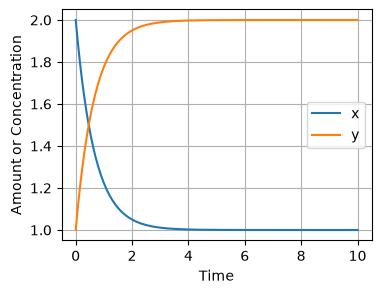

### Single compartment - at membrane

[figure not shown]

\[\begin{align*} v &= {\color{purple} A} \left( k_f \frac{n_x}{{\color{cyan}C_1} } - k_r \frac{n_y}{{\color{cyan}C_1}} \right) \\ &= f_f n_x - f_r n_y \\ &= f_f \left( n_x - \frac{n_y}{K_{eq}} \right)\\ \end{align*}\]

```python
m = (
    Model()
    .add_variables({"n_x": 2.0, "n_y": 1.0})
    .add_parameters(
        {
            "kf": 1.0,
            "keq": 2.0,
            "c1": 1.5,  # compartment volume
            "a1": 1.0,  # area of membrane
        }
    )
    # Now compartmentalise
    .add_derived("ff", rate_factor, args=["a1", "kf", "c1"])
    .add_derived("x_c1", fns.div, args=["n_x", "c1"])
    .add_derived("y_c1", fns.div, args=["n_y", "c1"])
    .add_reaction(
        "v1",
        ma_1s_1p_keq,
        args=["n_x", "n_y", "ff", "keq"],
        stoichiometry={"n_x": -1, "n_y": 1},
    )
)

c = Simulator(m).simulate(10).get_result().unwrap_or_err().variables
fig, (ax1, ax2) = plot.two_axes(figsize=(6, 3))
_ = plot.lines(
    c.loc[:, ["n_x", "n_y"]],
    ax=ax1,
    xlabel="Time",
    ylabel="Amount",
)
_ = plot.lines(
    c.loc[:, ["x_c1", "y_c1"]],
    ax=ax2,
    xlabel="Time",
    ylabel="Concentration",
)
```

m = ( Model() .add_variables({"n_x": 2.0, "n_y": 1.0}) .add_parameters( { "kf": 1.0, "keq": 2.0, "c1": 1.5, # compartment volume "a1": 1.0, # area of membrane } ) # Now compartmentalise .add_derived("ff", rate_factor, args=["a1", "kf", "c1"]) .add_derived("x_c1", fns.div, args=["n_x", "c1"]) .add_derived("y_c1", fns.div, args=["n_y", "c1"]) .add_reaction( "v1", ma_1s_1p_keq, args=["n_x", "n_y", "ff", "keq"], stoichiometry={"n_x": -1, "n_y": 1}, ) ) c = Simulator(m).simulate(10).get_result().unwrap_or_err().variables fig, (ax1, ax2) = plot.two_axes(figsize=(6, 3)) _ = plot.lines( c.loc[:, ["n_x", "n_y"]], ax=ax1, xlabel="Time", ylabel="Amount", ) _ = plot.lines( c.loc[:, ["x_c1", "y_c1"]], ax=ax2, xlabel="Time", ylabel="Concentration", )

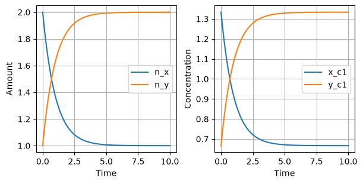

### Single compartment - on membrane

[figure not shown]

This special case depends only on the area of the membrane, not on the volume of the compartment

\[\begin{align*} v &= {\color{purple} A} \left( k_f \frac{n_x}{{\color{purple} A} } - k_r \frac{n_y}{{\color{purple} A} } \right) \\ &= f_f n_x - f_r n_y \\ &= f_f \left( n_x - \frac{n_y}{K_{eq}} \right)\\ \end{align*}\]

```python
m = (
    Model()
    .add_variables({"n_x": 2.0, "n_y": 1.0})
    .add_parameters(
        {
            "kf": 1.0,
            "keq": 2.0,
        }
    )
    .add_reaction(
        "v1",
        ma_1s_1p_keq,
        args=["n_x", "n_y", "kf", "keq"],
        stoichiometry={"n_x": -1, "n_y": 1},
    )
)

c = Simulator(m).simulate(10).get_result().unwrap_or_err().variables
_ = plot.lines(
    c.loc[:, ["n_x", "n_y"]],
    xlabel="Time",
    ylabel="Amount",
    ax=plot.one_axes(figsize=(4, 3))[1],
)
```

m = ( Model() .add_variables({"n_x": 2.0, "n_y": 1.0}) .add_parameters( { "kf": 1.0, "keq": 2.0, } ) .add_reaction( "v1", ma_1s_1p_keq, args=["n_x", "n_y", "kf", "keq"], stoichiometry={"n_x": -1, "n_y": 1}, ) ) c = Simulator(m).simulate(10).get_result().unwrap_or_err().variables _ = plot.lines( c.loc[:, ["n_x", "n_y"]], xlabel="Time", ylabel="Amount", ax=plot.one_axes(figsize=(4, 3))[1], )

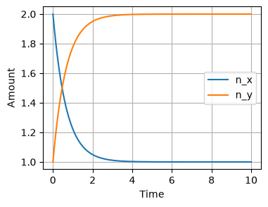

### Two compartments - diffusion accross membrane

[figure not shown]

\[\begin{align*} v &= {\color{purple} A} \left( k_f \frac{n_x}{{\color{cyan} C_1}} - k_r \frac{n_y}{{\color{coral} C_2}} \right) \\ &= f_f n_x - f_r n_y \\ &= f_f \left( n_x - \frac{n_y}{K_{eq}} \right)\\ \end{align*}\]

```python
m = (
    Model()
    .add_variables({"nx_c1": 2.0, "ny_c2": 1.0})
    .add_parameters({"kf": 1.0, "keq": 2.0, "c1": 1.5, "c2": 0.5})
    # Now compartmentalise
    .add_derived("ff", fns.div, args=["kf", "c1"])
    .add_derived("x_c1", fns.div, args=["nx_c1", "c1"])
    .add_derived("x_c2", fns.div, args=["ny_c2", "c2"])
    .add_reaction(
        "v1",
        ma_1s_1p_keq,
        args=["nx_c1", "ny_c2", "ff", "keq"],
        stoichiometry={"nx_c1": -1, "ny_c2": 1},
    )
)

c = Simulator(m).simulate(10).get_result().unwrap_or_err().variables
fig, (ax1, ax2) = plot.two_axes(figsize=(6, 3))
_ = plot.lines(
    c.loc[:, ["nx_c1", "ny_c2"]],
    ax=ax1,
    xlabel="Time",
    ylabel="Amount",
)
_ = plot.lines(
    c.loc[:, ["x_c1", "x_c2"]],
    ax=ax2,
    xlabel="Time",
    ylabel="Concentration",
)
```

[output not shown]

m = ( Model() .add_variables({"nx_c1": 2.0, "ny_c2": 1.0}) .add_parameters({"kf": 1.0, "keq": 2.0, "c1": 1.5, "c2": 0.5}) # Now compartmentalise .add_derived("ff", fns.div, args=["kf", "c1"]) .add_derived("x_c1", fns.div, args=["nx_c1", "c1"]) .add_derived("x_c2", fns.div, args=["ny_c2", "c2"]) .add_reaction( "v1", ma_1s_1p_keq, args=["nx_c1", "ny_c2", "ff", "keq"], stoichiometry={"nx_c1": -1, "ny_c2": 1}, ) ) c = Simulator(m).simulate(10).get_result().unwrap_or_err().variables fig, (ax1, ax2) = plot.two_axes(figsize=(6, 3)) _ = plot.lines( c.loc[:, ["nx_c1", "ny_c2"]], ax=ax1, xlabel="Time", ylabel="Amount", ) _ = plot.lines( c.loc[:, ["x_c1", "x_c2"]], ax=ax2, xlabel="Time", ylabel="Concentration", )

### Two compartments - inside

[figure not shown]

\[\begin{align*} v &= {\color{purple} A} \left( k_f \frac{n_x}{{\color{cyan} C_1}} - k_r \frac{n_y}{{\color{coral} C_2}} \right) \\ &= f_f n_x - f_r n_y \\ &= f_f \left( n_x - \frac{n_y}{K_{eq}} \right)\\ \end{align*}\]

```python
m = (
    Model()
    .add_variables({"nx_c1": 2.0, "ny_c2": 1.0})
    .add_parameters({"kf": 1.0, "keq": 2.0, "c1": 1.5, "c2": 0.5})
    # Now compartmentalise
    .add_derived("ff", fns.div, args=["kf", "c1"])
    .add_derived("x_c1", fns.div, args=["nx_c1", "c1"])
    .add_derived("x_c2", fns.div, args=["ny_c2", "c2"])
    .add_reaction(
        "v1",
        ma_1s_1p_keq,
        args=["nx_c1", "ny_c2", "ff", "keq"],
        stoichiometry={"nx_c1": -1, "ny_c2": 1},
    )
)

c = Simulator(m).simulate(10).get_result().unwrap_or_err().variables
fig, (ax1, ax2) = plot.two_axes(figsize=(6, 3))
_ = plot.lines(
    c.loc[:, ["nx_c1", "ny_c2"]],
    ax=ax1,
    xlabel="Time",
    ylabel="Amount",
)
_ = plot.lines(
    c.loc[:, ["x_c1", "x_c2"]],
    ax=ax2,
    xlabel="Time",
    ylabel="Concentration",
)
```

[output not shown]

m = ( Model() .add_variables({"nx_c1": 2.0, "ny_c2": 1.0}) .add_parameters({"kf": 1.0, "keq": 2.0, "c1": 1.5, "c2": 0.5}) # Now compartmentalise .add_derived("ff", fns.div, args=["kf", "c1"]) .add_derived("x_c1", fns.div, args=["nx_c1", "c1"]) .add_derived("x_c2", fns.div, args=["ny_c2", "c2"]) .add_reaction( "v1", ma_1s_1p_keq, args=["nx_c1", "ny_c2", "ff", "keq"], stoichiometry={"nx_c1": -1, "ny_c2": 1}, ) ) c = Simulator(m).simulate(10).get_result().unwrap_or_err().variables fig, (ax1, ax2) = plot.two_axes(figsize=(6, 3)) _ = plot.lines( c.loc[:, ["nx_c1", "ny_c2"]], ax=ax1, xlabel="Time", ylabel="Amount", ) _ = plot.lines( c.loc[:, ["x_c1", "x_c2"]], ax=ax2, xlabel="Time", ylabel="Concentration", )

### Two compartments - at membrane

[figure not shown]

\[\begin{align*} v &= {\color{purple} A} \left( k_f \frac{n_x}{{\color{cyan} C_1}} - k_r \frac{n_y}{{\color{coral} C_2}} \right) \\ &= f_f n_x - f_r n_y \\ &= f_f \left( n_x - \frac{n_y}{K_{eq}} \right)\\ \end{align*}\]

```python
m = (
    Model()
    .add_variables({"nx_c1": 2.0, "ny_c2": 1.0})
    .add_parameters({"kf": 1.0, "keq": 2.0, "c1": 1.5, "c2": 0.5})
    # Now compartmentalise
    .add_derived("ff", fns.div, args=["kf", "c1"])
    .add_derived("x_c1", fns.div, args=["nx_c1", "c1"])
    .add_derived("x_c2", fns.div, args=["ny_c2", "c2"])
    .add_reaction(
        "v1",
        ma_1s_1p_keq,
        args=["nx_c1", "ny_c2", "ff", "keq"],
        stoichiometry={"nx_c1": -1, "ny_c2": 1},
    )
)

c = Simulator(m).simulate(10).get_result().unwrap_or_err().variables
fig, (ax1, ax2) = plot.two_axes(figsize=(6, 3))
_ = plot.lines(
    c.loc[:, ["nx_c1", "ny_c2"]],
    ax=ax1,
    xlabel="Time",
    ylabel="Amount",
)
_ = plot.lines(
    c.loc[:, ["x_c1", "x_c2"]],
    ax=ax2,
    xlabel="Time",
    ylabel="Concentration",
)
```

[output not shown]

m = ( Model() .add_variables({"nx_c1": 2.0, "ny_c2": 1.0}) .add_parameters({"kf": 1.0, "keq": 2.0, "c1": 1.5, "c2": 0.5}) # Now compartmentalise .add_derived("ff", fns.div, args=["kf", "c1"]) .add_derived("x_c1", fns.div, args=["nx_c1", "c1"]) .add_derived("x_c2", fns.div, args=["ny_c2", "c2"]) .add_reaction( "v1", ma_1s_1p_keq, args=["nx_c1", "ny_c2", "ff", "keq"], stoichiometry={"nx_c1": -1, "ny_c2": 1}, ) ) c = Simulator(m).simulate(10).get_result().unwrap_or_err().variables fig, (ax1, ax2) = plot.two_axes(figsize=(6, 3)) _ = plot.lines( c.loc[:, ["nx_c1", "ny_c2"]], ax=ax1, xlabel="Time", ylabel="Amount", ) _ = plot.lines( c.loc[:, ["x_c1", "x_c2"]], ax=ax2, xlabel="Time", ylabel="Concentration", )

### Two compartments - on membrane

[figure not shown]

\[\begin{align*} v &= {\color{purple} A} \left( k_f \frac{n_x}{{\color{purple} A}} - k_r \frac{n_y}{{\color{purple} A}} \right) \\ &= f_f n_x - f_r n_y \\ &= f_f \left( n_x - \frac{n_y}{K_{eq}} \right)\\ \end{align*}\]

```python
m = (
    Model()
    .add_variables({"nx_c1": 2.0, "ny_c2": 1.0})
    .add_parameters({"kf": 1.0, "keq": 2.0, "c1": 1.5, "c2": 0.5})
    # Now compartmentalise
    .add_derived("ff", fns.div, args=["kf", "c1"])
    .add_derived("x_c1", fns.div, args=["nx_c1", "c1"])
    .add_derived("x_c2", fns.div, args=["ny_c2", "c2"])
    .add_reaction(
        "v1",
        ma_1s_1p_keq,
        args=["nx_c1", "ny_c2", "ff", "keq"],
        stoichiometry={"nx_c1": -1, "ny_c2": 1},
    )
)

c = Simulator(m).simulate(10).get_result().unwrap_or_err().variables
fig, (ax1, ax2) = plot.two_axes(figsize=(6, 3))
_ = plot.lines(
    c.loc[:, ["nx_c1", "ny_c2"]],
    ax=ax1,
    xlabel="Time",
    ylabel="Amount",
)
_ = plot.lines(
    c.loc[:, ["x_c1", "x_c2"]],
    ax=ax2,
    xlabel="Time",
    ylabel="Concentration",
)
```

[output not shown]

m = ( Model() .add_variables({"nx_c1": 2.0, "ny_c2": 1.0}) .add_parameters({"kf": 1.0, "keq": 2.0, "c1": 1.5, "c2": 0.5}) # Now compartmentalise .add_derived("ff", fns.div, args=["kf", "c1"]) .add_derived("x_c1", fns.div, args=["nx_c1", "c1"]) .add_derived("x_c2", fns.div, args=["ny_c2", "c2"]) .add_reaction( "v1", ma_1s_1p_keq, args=["nx_c1", "ny_c2", "ff", "keq"], stoichiometry={"nx_c1": -1, "ny_c2": 1}, ) ) c = Simulator(m).simulate(10).get_result().unwrap_or_err().variables fig, (ax1, ax2) = plot.two_axes(figsize=(6, 3)) _ = plot.lines( c.loc[:, ["nx_c1", "ny_c2"]], ax=ax1, xlabel="Time", ylabel="Amount", ) _ = plot.lines( c.loc[:, ["x_c1", "x_c2"]], ax=ax2, xlabel="Time", ylabel="Concentration", )

### Two compartments - onto / off membrane

[figure not shown]

\[\begin{align*} v &= {\color{purple} A} \left( k_f \frac{n_x}{{\color{cyan} C_1}} - k_r \frac{n_y}{{\color{purple} A} } \right) \\ &= f_f n_x - f_r n_y \\ &= f_f \left( n_x - \frac{n_y}{K_{eq}} \right)\\ \end{align*}\]

```python
m = (
    Model()
    .add_variables({"nx_c1": 2.0, "ny_a": 1.0})
    .add_parameters({"kf": 1.0, "keq": 2.0, "c1": 1.5, "a": 0.5})
    # Now compartmentalise
    .add_derived("ff", rate_factor, args=["a", "kf", "c1"])
    .add_derived("x_c1", fns.div, args=["nx_c1", "c1"])
    .add_reaction(
        "v1",
        ma_1s_1p_keq,
        args=["nx_c1", "ny_a", "ff", "keq"],
        stoichiometry={"nx_c1": -1, "ny_a": 1},
    )
)

c = Simulator(m).simulate(10).get_result().unwrap_or_err().variables
fig, (ax1, ax2) = plot.two_axes(figsize=(6, 3))
_ = plot.lines(
    c.loc[:, ["nx_c1", "ny_a"]],
    ax=ax1,
    xlabel="Time",
    ylabel="Amount",
)
_ = plot.lines(
    c.loc[:, ["x_c1"]],
    ax=ax2,
    xlabel="Time",
    ylabel="Concentration",
)
```

m = ( Model() .add_variables({"nx_c1": 2.0, "ny_a": 1.0}) .add_parameters({"kf": 1.0, "keq": 2.0, "c1": 1.5, "a": 0.5}) # Now compartmentalise .add_derived("ff", rate_factor, args=["a", "kf", "c1"]) .add_derived("x_c1", fns.div, args=["nx_c1", "c1"]) .add_reaction( "v1", ma_1s_1p_keq, args=["nx_c1", "ny_a", "ff", "keq"], stoichiometry={"nx_c1": -1, "ny_a": 1}, ) ) c = Simulator(m).simulate(10).get_result().unwrap_or_err().variables fig, (ax1, ax2) = plot.two_axes(figsize=(6, 3)) _ = plot.lines( c.loc[:, ["nx_c1", "ny_a"]], ax=ax1, xlabel="Time", ylabel="Amount", ) _ = plot.lines( c.loc[:, ["x_c1"]], ax=ax2, xlabel="Time", ylabel="Concentration", )

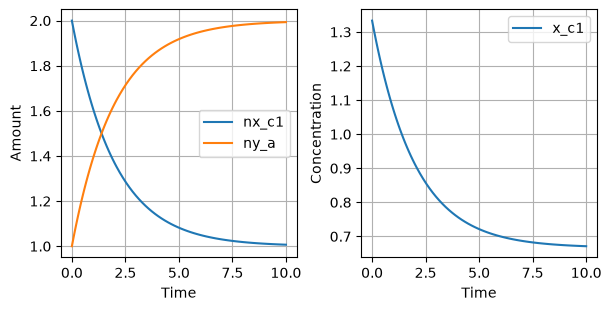

[figure not shown]

\[\begin{align*} v &= {\color{purple} A} \left( k_f \frac{n_x}{{\color{purple} A} } - k_r \frac{n_y}{{\color{coral} C_2}} \right) \\ &= f_f n_x - f_r n_y \\ &= f_f \left( n_x - \frac{n_y}{K_{eq}} \right)\\ \end{align*}\]

```python
m = (
    Model()
    .add_variables({"nx_a": 2.0, "ny_c2": 1.0})
    .add_parameters({"kf": 1.0, "keq": 2.0, "c2": 1.5, "a": 0.5})
    # Now compartmentalise
    .add_derived("ff", rate_factor, args=["a", "kf", "a"])
    .add_derived("y_c2", fns.div, args=["nx_a", "c2"])
    .add_reaction(
        "v1",
        ma_1s_1p_keq,
        args=["nx_a", "ny_c2", "ff", "keq"],
        stoichiometry={"nx_a": -1, "ny_c2": 1},
    )
)

c = Simulator(m).simulate(10).get_result().unwrap_or_err().variables
fig, (ax1, ax2) = plot.two_axes(figsize=(6, 3))
_ = plot.lines(
    c.loc[:, ["nx_a", "ny_c2"]],
    ax=ax1,
    xlabel="Time",
    ylabel="Amount",
)
_ = plot.lines(
    c.loc[:, ["y_c2"]],
    ax=ax2,
    xlabel="Time",
    ylabel="Concentration",
)
```

m = ( Model() .add_variables({"nx_a": 2.0, "ny_c2": 1.0}) .add_parameters({"kf": 1.0, "keq": 2.0, "c2": 1.5, "a": 0.5}) # Now compartmentalise .add_derived("ff", rate_factor, args=["a", "kf", "a"]) .add_derived("y_c2", fns.div, args=["nx_a", "c2"]) .add_reaction( "v1", ma_1s_1p_keq, args=["nx_a", "ny_c2", "ff", "keq"], stoichiometry={"nx_a": -1, "ny_c2": 1}, ) ) c = Simulator(m).simulate(10).get_result().unwrap_or_err().variables fig, (ax1, ax2) = plot.two_axes(figsize=(6, 3)) _ = plot.lines( c.loc[:, ["nx_a", "ny_c2"]], ax=ax1, xlabel="Time", ylabel="Amount", ) _ = plot.lines( c.loc[:, ["y_c2"]], ax=ax2, xlabel="Time", ylabel="Concentration", )

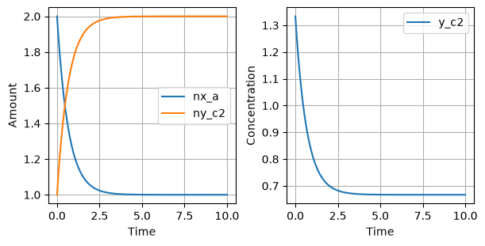

## First finish line

With that you now know most of what you will need from a day-to-day basis about compartmentalisation in mxlpy.  
Congratulations!